# Final project: ARIMAX Model for Gasoline Consumption

Berta Pla i Casamitjana and Fèlix Real Fraxedas

May 2023

# Introduction

This is the final project of the Time Series course of the Master’s Degree in Statistics and Operations Research. This project aims to apply the Box-Jenkins ARIMA methodology, including extensions for treatment of calendar effects and outliers, to the analysis and prediction of a chosen “real time series”. Summarizing, it will consist in applying all the knowledge that we have acquired during the first part of the course.

In our case, we decided to choose the time series about the Gasoline consumption in Spain, with data from Ministerio de Fomento. It is an interesting Time Series, as the gasoline consumption will likely have stational components (in summer people tend to travel more) and also calendar effects (Easter, for example) or outliers.

We have loaded the function $\texttt{validation}$ that has been used throughout the course (we have omitted the chunk).

As always, the first step is to load and take a first look at the data:

```r
setwd(".")
serie=window(ts(read.table("gasolina.dat"),start=1993,freq=12))
```

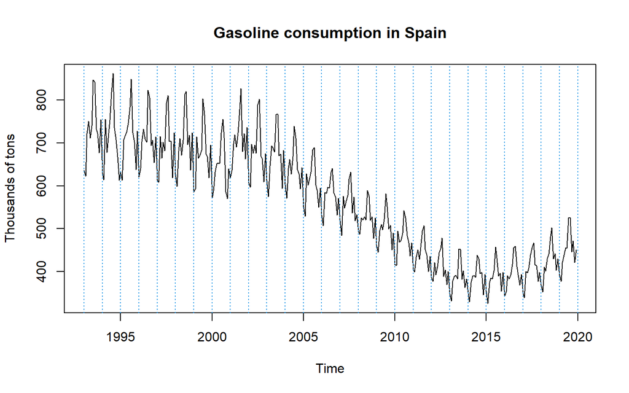

```r
plot(serie, main="Gasoline consumption in Spain", ylab="Thousands of tons")
abline(v=1993:2020,lty=3,col=4)
```

# Identification

This first section will be divided into two parts:

1. Making the series stationary, using different transformations.
2. Analyse the ACF and PACF of the stationary series to identify possible models, as well as seeing if there are possible calendar effects or outliers.

## Making the series stationary

The first step will be to check if the variance is constant throughout the series. In the base plot of the series we have seen before, we can already guess that the years in which the mean is higher, so is the variance, but let’s check it by making a mean-variance plot:

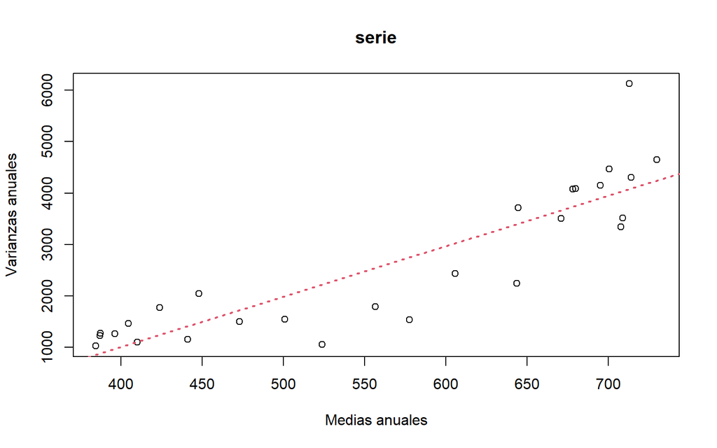

```r
m = apply(matrix(serie, nr=12), 2, mean)
v = apply(matrix(serie, nr=12), 2, var)
plot(m, v, xlab="Medias anuales", ylab="Varianzas anuales", main="serie")
abline(lm(v~m), col=2, lty=3, lwd=2)
```

With this plot we confirm that the variance is not constant (higher mean implies higher variance), so a first transformation is clear to do: a logarithm.

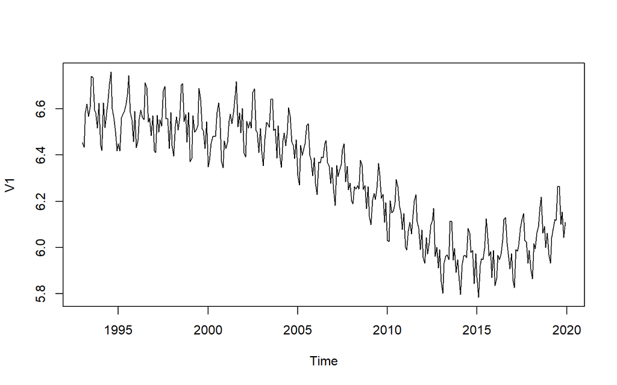

```r
lnserie <- log(serie)
plot(lnserie)
```

Let’s repeat the mean-variance plot to check we have eliminated the non-constant variance:

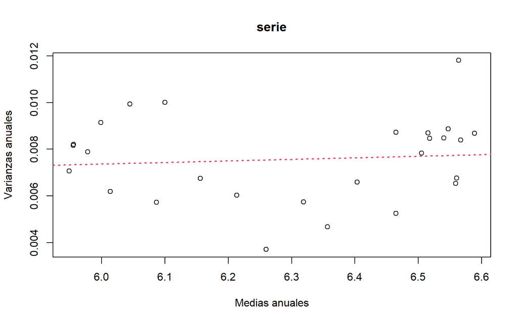

```r
m = apply(matrix(lnserie, nr=12), 2, mean)
v = apply(matrix(lnserie, nr=12), 2, var)
plot(m, v, xlab="Medias anuales", ylab="Varianzas anuales", main="serie")
abline(lm(v~m), col=2, lty=3, lwd=2)
```

Now that we have a constant variance, let’s look at another clear point we have seen in the initial plot: the seasonality. There is a clear yearly seasonality, so let’s check it with a $\texttt{monthplot}$:

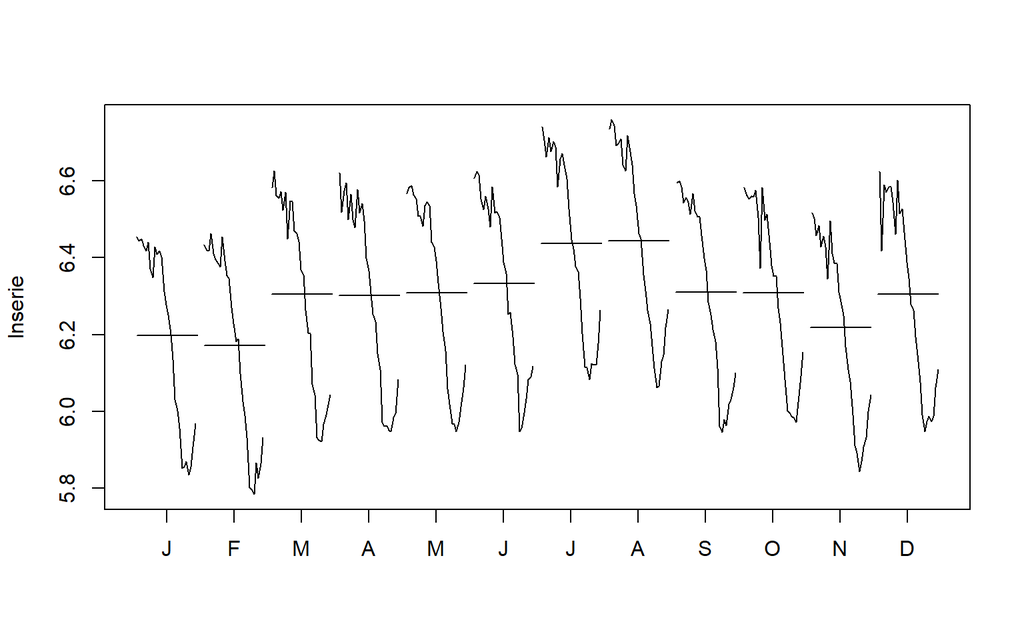

```r
monthplot(lnserie)
```

As we could expect, the gasoline consumption is higher in the summer months (when people tend to go on holiday). We confirm the yearly seasonality, so we perform a 12-order differentiation and plot the resulting series:

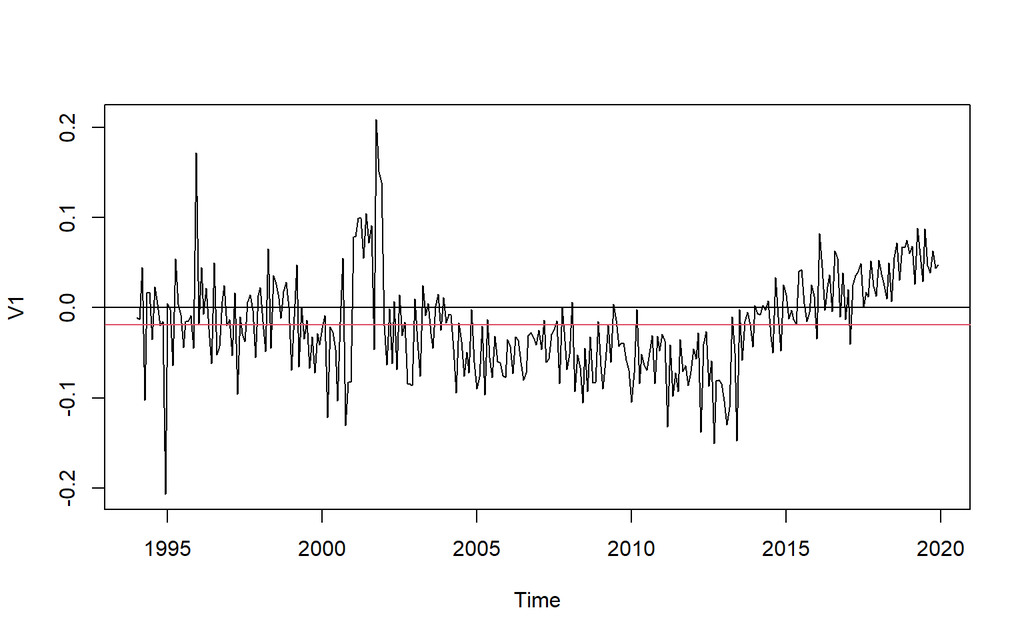

```r
d12lnserie=diff(lnserie,12)
plot(d12lnserie)
abline(h=0)
abline(h=mean(d12lnserie),col=2)
```

In the previous plot, we see that the general mean of the transformed series is almost zero, but is not clearly constant already, so we can try a regular differentiation and see what we obtain:

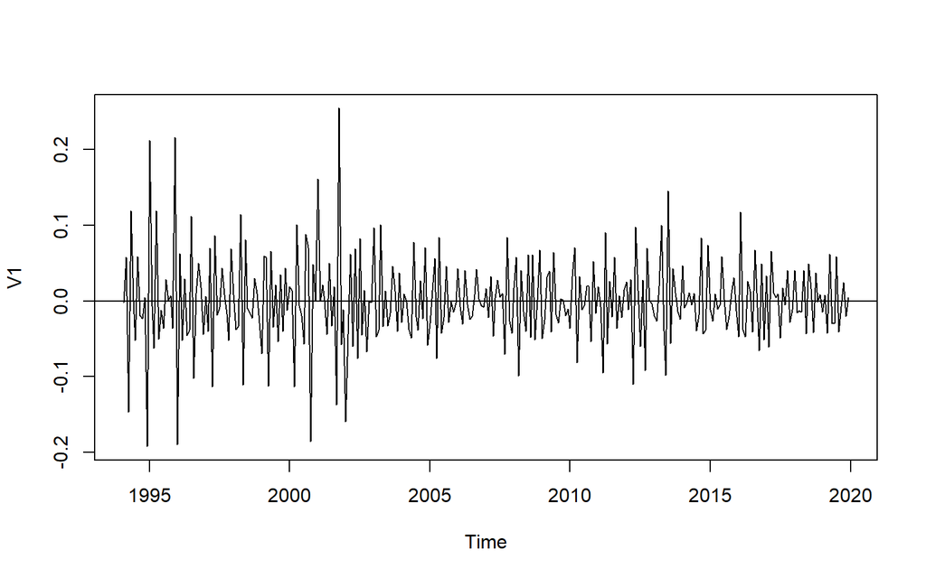

```r
d1d12lnserie=diff(d12lnserie,1)
plot(d1d12lnserie)
abline(h=0)
```

Now the mean is clearly constant and equal to zero. However, there exists the possibility that we have artificially added variance (over-differentiated). For that reason, we have to compute the variances and see if that is the case:

```r
var(lnserie)
```

```
##            V1
## V1 0.06263059
```

```r
var(d12lnserie)
```

```
##             V1
## V1 0.002996946
```

```r
var(d1d12lnserie)
```

```
##             V1
## V1 0.003333053
```

We see a slightly higher variance in the two times differentiated series, but as the difference is not that high and the series seems to have a better stationary structure in that way, we decide to keep the seasonal and regular differentiated series.

```r
data <- d1d12lnserie
```

## Identifying possible models by looking at the ACF/PACF structure

Now that we have a stationary series, we can proceed to identify possible ARMA models that fit it. To do so, we will look at the ACF/PACF structure:

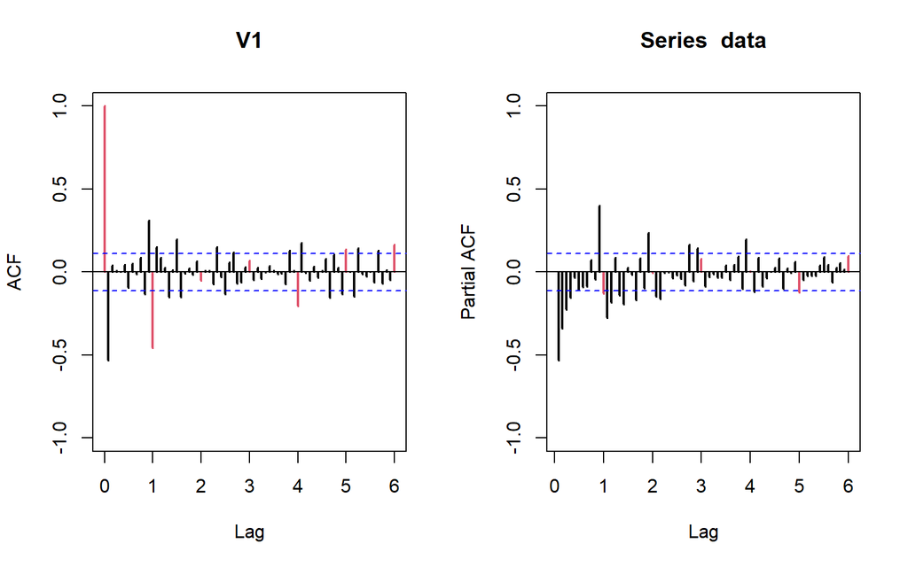

```r
par(mfrow=c(1,2))
acf(data, ylim=c(-1,1), col=c(2,rep(1,11)),lwd=2,lag.max=72)
pacf(data, ylim=c(-1,1), col=c(rep(1,11),2),lwd=2,lag.max=72)
```

```r
par(mfrow=c(1,1))
```

From the previous ACF/PACF plots, we identify these structures:

- For the seasonal part, we see an $MA(1)$ structure (one non-null ACF lag in the seasonal part after the first one).
- For the regular part, we can see an $ARMA(1,1)$ (if we consider both the ACF and PACF to decay slowly) or an $MA(1)$ structure (the ACF decreases faster than the PACF). We could also consider an $AR(4)$ structure, as there are 4 non-null lags on the PACF, but we will avoid using that large number of parameters.

All in all, we will consider the models with the less parameters to make things easier and so, we will consider:

- $ARMA(0,0,1)(0,0,1)_{12}$
- $ARMA(1,0,1)(0,0,1)_{12}$

# Estimation

After transforming our series into a stationary one and identifying two possible models for the series, we do actually fit the models. We first try them including the mean, despite already knowing that we will probably will have to get rid of it (since we have seen that it is zero).

```r
(mod1=arima(data,order=c(0,0,1),seasonal=list(order=c(0,0,1),period=12)))
```

```
##
## Call:
## arima(x = data, order = c(0, 0, 1), seasonal = list(order = c(0, 0, 1), period = 12))
##
## Coefficients:
##           ma1     sma1  intercept
##       -0.6778  -0.8917      1e-04
## s.e.   0.0354   0.0476      1e-04
##
## sigma^2 estimated as 0.001079:  log likelihood = 611.26,  aic = -1214.51
```

```r
(mod2=arima(data,order=c(1,0,1),seasonal=list(order=c(0,0,1),period=12)))
```

```
##
## Call:
## arima(x = data, order = c(1, 0, 1), seasonal = list(order = c(0, 0, 1), period = 12))
##
## Coefficients:
##           ar1      ma1     sma1  intercept
##       -0.1695  -0.6037  -0.8769      1e-04
## s.e.   0.0747   0.0560   0.0458      1e-04
##
## sigma^2 estimated as 0.001067:  log likelihood = 613.73,  aic = -1217.45
```

As we expected, we see that the intercepts are not significant (apart from being almost zero in both cases), so we fit the models without them and then we will check the significance of the coefficients by looking at the t-ratios:

$$t_i =
\frac{\phi_i}{sd(\phi_i)}$$

which will indicate that the coefficient $\phi_i$ is significant if $|t_i| > 2$.

```r
(mod1=arima(lnserie,order=c(0,1,1),seasonal=list(order=c(0,1,1),period=12)))
```

```
##
## Call:
## arima(x = lnserie, order = c(0, 1, 1), seasonal = list(order = c(0, 1, 1), period = 12))
##
## Coefficients:
##           ma1     sma1
##       -0.6756  -0.8916
## s.e.   0.0355   0.0472
##
## sigma^2 estimated as 0.001081:  log likelihood = 610.97,  aic = -1215.93
```

```r
(mod2=arima(lnserie,order=c(1,1,1),seasonal=list(order=c(0,1,1),period=12)))
```

```
##
## Call:
## arima(x = lnserie, order = c(1, 1, 1), seasonal = list(order = c(0, 1, 1), period = 12))
##
## Coefficients:
##           ar1      ma1     sma1
##       -0.1707  -0.6006  -0.8770
## s.e.   0.0747   0.0562   0.0455
##
## sigma^2 estimated as 0.001068:  log likelihood = 613.46,  aic = -1218.93
```

```r
# Extract the estimated coefficients and covariance matrix
coef_est <- mod1$coef
cov_mat <- mod1$var.coef

# Compute the t-ratios
t_ratios_1 <- coef_est / sqrt(diag(cov_mat))

# Print the results
print(abs(t_ratios_1))
```

```
##      ma1     sma1
## 19.03410 18.89423
```

```r
# Extract the estimated coefficients and covariance matrix
coef_est <- mod2$coef
cov_mat <- mod2$var.coef

# Compute the t-ratios
t_ratios_2 <- coef_est / sqrt(diag(cov_mat))

# Print the results
print(abs(t_ratios_2))
```

```
##      ar1      ma1     sma1
##  2.28424 10.68245 19.26075
```

So, in both models, the coefficients are all significant. For the moment, we keep both models, the $ARMA(0,1,1)(0,1,1)_{12}$ and the $ARMA(1,1,1)(0,1,1)_{12}$, both fitting the logarithm of the original series.

# Validation

After having estimated both models, we will use the $\texttt{validate}$ function used throughout the course to see if the assumptions of the ARIMA model are fulfilled. We will check the following characteristics of the model:

- Residuals should be normal with zero mean and constant variance
- The residuals should be independent
- We will check whether the models are causal and/or invertible
- If the sample and theoretical ACF/PACF are similar

## $ARMA(0,1,1)(0,1,1)_{12}$ model

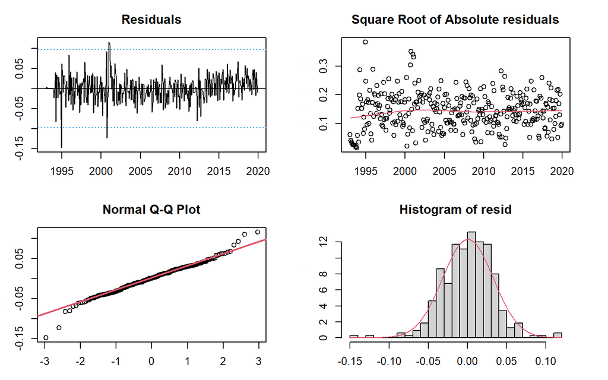

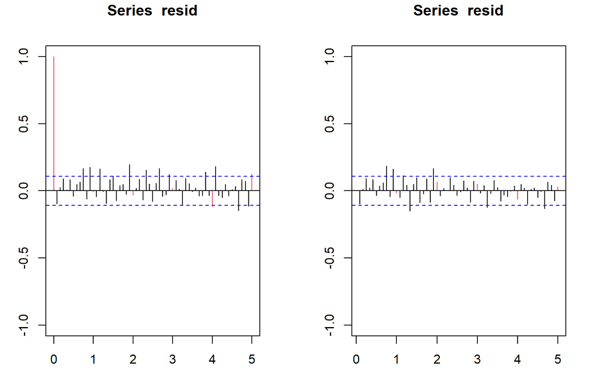

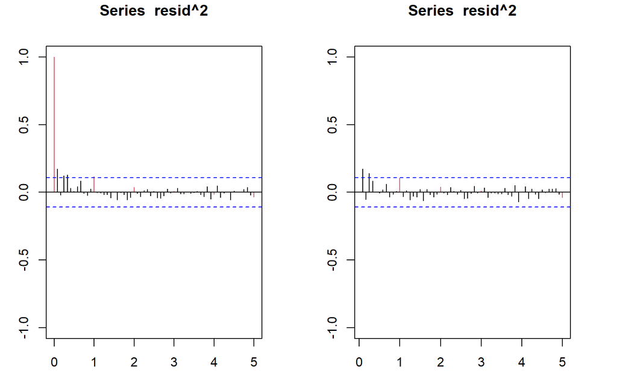

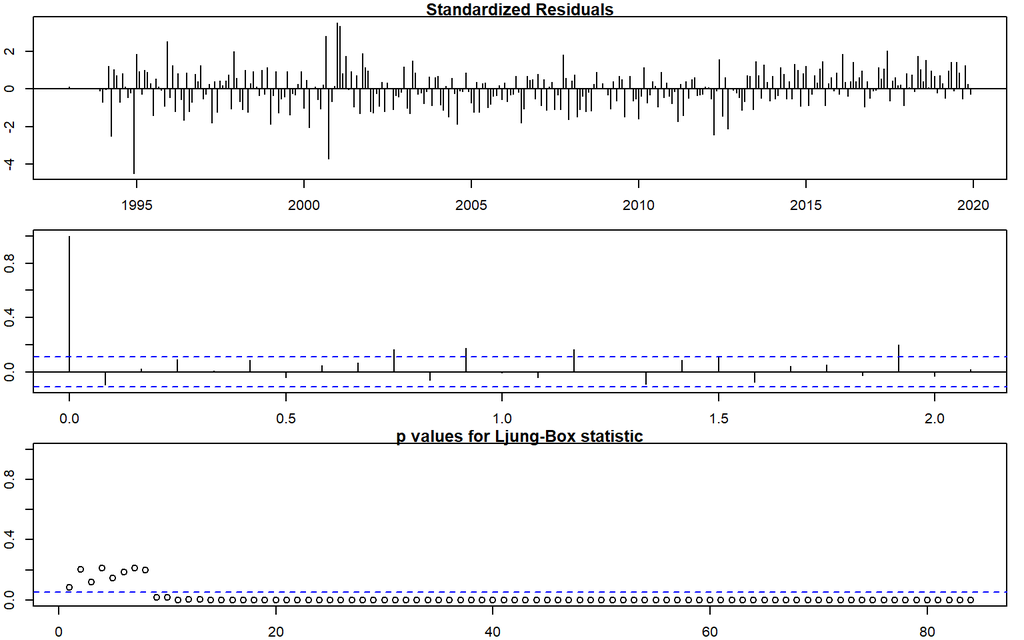

```
##
## --------------------------------------------------------------------
##
## Call:
## arima(x = lnserie, order = c(0, 1, 1), seasonal = list(order = c(0, 1, 1), period = 12))
##
## Coefficients:
##           ma1     sma1
##       -0.6756  -0.8916
## s.e.   0.0355   0.0472
##
## sigma^2 estimated as 0.001081:  log likelihood = 610.97,  aic = -1215.93
##
## Modul of AR Characteristic polynomial Roots:
##
## Modul of MA Characteristic polynomial Roots:  1.009607 1.009607 1.009607 1.009607 1.009607 1.009607 1.009607 1.009607 1.009607 1.009607 1.009607 1.009607 1.480175
##
## Psi-weights (MA(inf))
##
## --------------------
##      psi 1      psi 2      psi 3      psi 4      psi 5      psi 6      psi 7
## -0.6755959  0.0000000  0.0000000  0.0000000  0.0000000  0.0000000  0.0000000
##      psi 8      psi 9     psi 10     psi 11     psi 12     psi 13     psi 14
##  0.0000000  0.0000000  0.0000000  0.0000000 -0.8915990  0.6023606  0.0000000
##     psi 15     psi 16     psi 17     psi 18     psi 19     psi 20
##  0.0000000  0.0000000  0.0000000  0.0000000  0.0000000  0.0000000
##
## Pi-weights (AR(inf))
##
## --------------------
##        pi 1        pi 2        pi 3        pi 4        pi 5        pi 6
## -0.67559593 -0.45642986 -0.30836215 -0.20832822 -0.14074569 -0.09508722
##        pi 7        pi 8        pi 9       pi 10       pi 11       pi 12
## -0.06424054 -0.04340065 -0.02932130 -0.01980935 -0.01338312 -0.90064055
##       pi 13       pi 14       pi 15       pi 16       pi 17       pi 18
## -0.60846909 -0.41107924 -0.27772346 -0.18762884 -0.12676128 -0.08563940
##       pi 19       pi 20
## -0.05785763 -0.03908838
##
## Normality Tests
```

[output cut: 37 more lines]

```
## data:  resid(model) ~ I(1:length(resid(model)))
## DW = 2.2219, p-value = 0.9743
## alternative hypothesis: true autocorrelation is greater than 0
##
##
## Ljung-Box test
##      lag.df  statistic      p.value
## [1,]      1   2.991605 8.369715e-02
## [2,]      2   3.176779 2.042543e-01
## [3,]      3   5.834868 1.199265e-01
## [4,]      4   5.847109 2.108610e-01
## [5,]     12  31.969196 1.399011e-03
## [6,]     24  69.018268 3.076141e-06
## [7,]     36 103.146369 2.138938e-08
## [8,]     48 128.113978 3.210882e-09
```

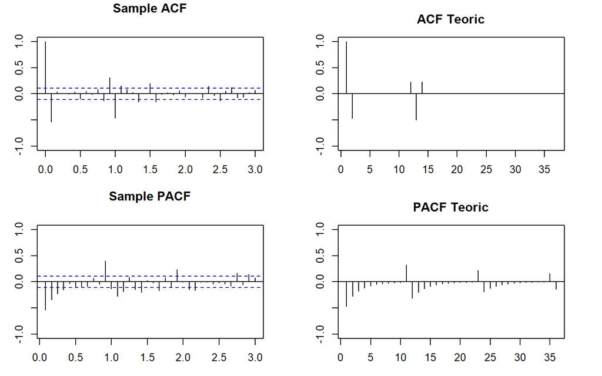

```r
validation(mod1, d1d12lnserie)
```

For this first model we see:

- We probably have outliers (at least 3 or 4 looking at Q-Q plot and histogram) that make the premises of the model not being fulfilled completely.
- In the ACF/PACF of the square of residulas there are some non-null lags that confirm that the variance is not completely homogeneous, probably due to the previously mentioned outliers.
- From the normality tests, we see that the only one that accepts it is the Anderson Darling test, which is not that sensitive to outliers.
- In the test, homoscedasticity is accepted.
- The independence of residuals is accepted in the Durbin Watson test, but not in the Ljung-Box, in which the p-values are below 0.05 from lag 9 onwards.
- The sample and theoretical ACF/PACF are quite similar, it can be seen in the figures. Some adequacy measures are the log-likelihood, 610.97, the AIC, -1215.93 and $\sigma^2 = 0.001081$.

Finally, we check whether the model is causal and/or invertible:

- The proposed $ARMA(0,1,1)(0,1,1)_{12}$ model is found invertible since all of the roots of the regular MA-characteristic polynomial lie outside the unit circle (all with modul between 1.009607 and 1.480175, which is greater than one). Thus, the model can be represented as a convergent AR(∞) expression with π-weights (useful for estimating point predictions).
- The model is also causal/stationary; since all MA(q) models are stationary. Thus, the model can be represented as a convergent MA(∞) expression with ψ-weights (useful for estimating the variance of estimated point predictions).

## $ARMA(1,1,1)(0,1,1)_{12}$ model

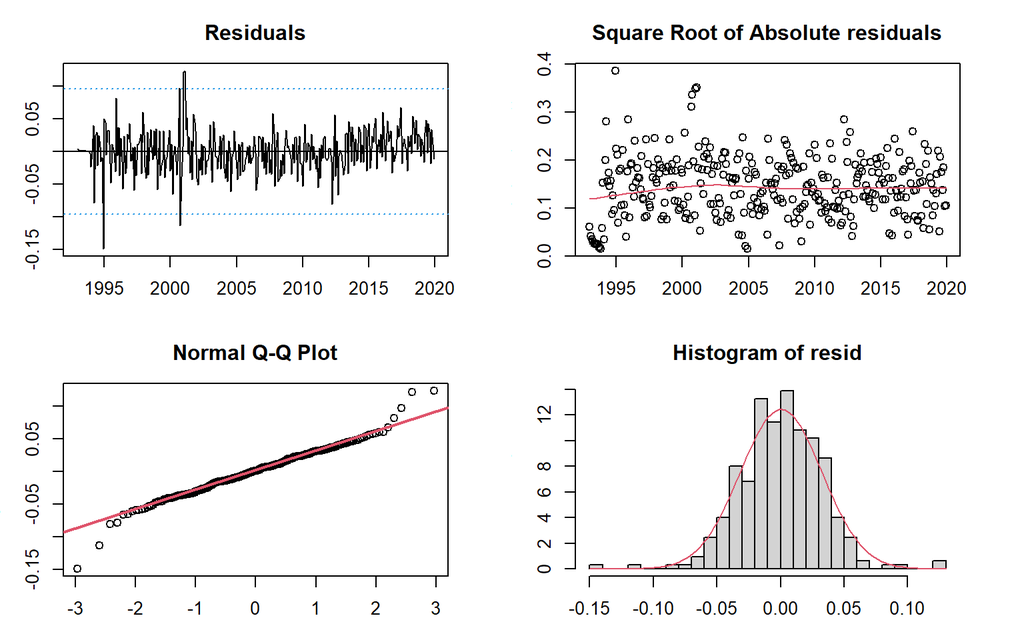

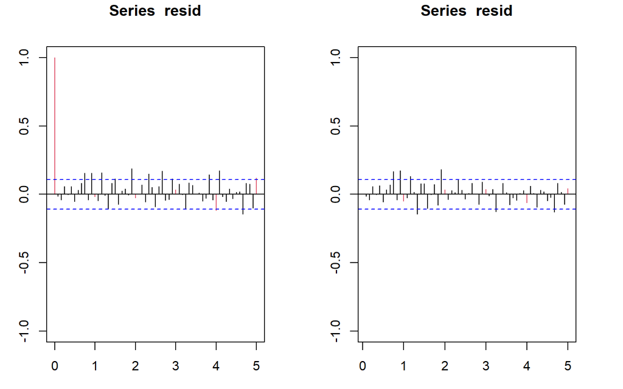

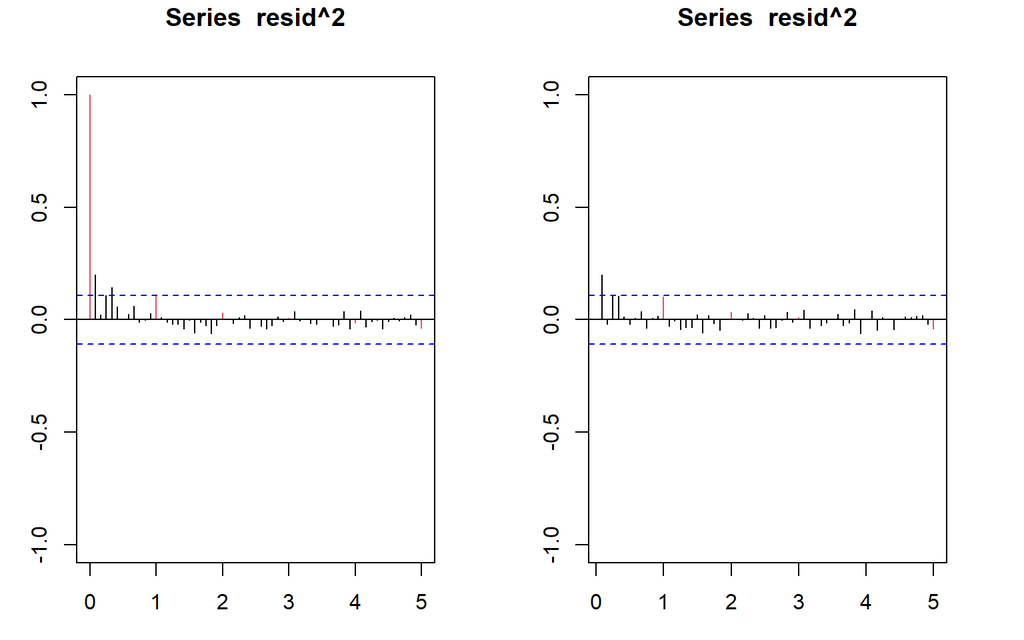

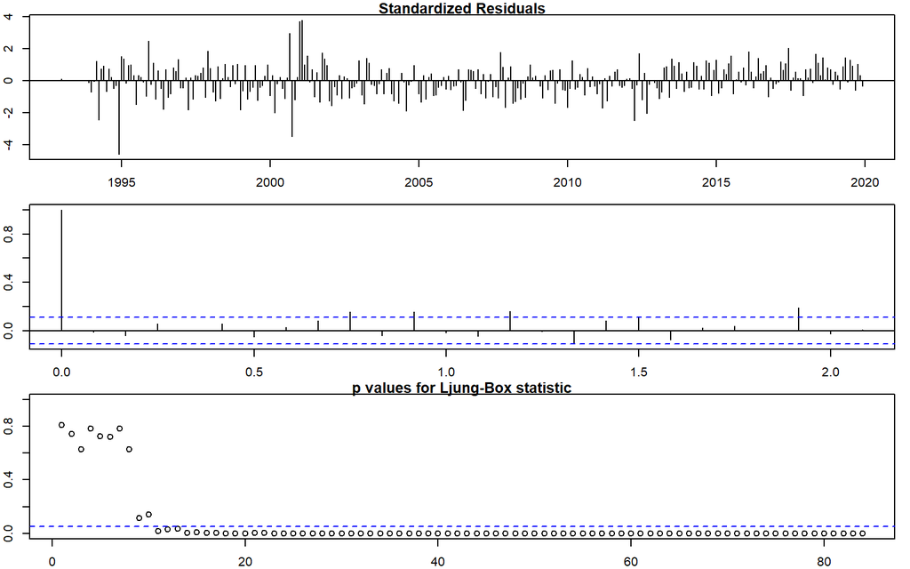

```
##
## --------------------------------------------------------------------
##
## Call:
## arima(x = lnserie, order = c(1, 1, 1), seasonal = list(order = c(0, 1, 1), period = 12))
##
## Coefficients:
##           ar1      ma1     sma1
##       -0.1707  -0.6006  -0.8770
## s.e.   0.0747   0.0562   0.0455
##
## sigma^2 estimated as 0.001068:  log likelihood = 613.46,  aic = -1218.93
##
## Modul of AR Characteristic polynomial Roots:  5.857139
##
## Modul of MA Characteristic polynomial Roots:  1.011001 1.011001 1.011001 1.011001 1.011001 1.011001 1.011001 1.011001 1.011001 1.011001 1.011001 1.011001 1.665005
##
## Psi-weights (MA(inf))
##
## --------------------
##         psi 1         psi 2         psi 3         psi 4         psi 5
## -7.713308e-01  1.316907e-01 -2.248380e-02  3.838700e-03 -6.553882e-04
##         psi 6         psi 7         psi 8         psi 9        psi 10
##  1.118956e-04 -1.910415e-05  3.261686e-06 -5.568736e-07  9.507604e-08
##        psi 11        psi 12        psi 13        psi 14        psi 15
## -1.623251e-08 -8.769654e-01  6.764304e-01 -1.154882e-01  1.971751e-02
##        psi 16        psi 17        psi 18        psi 19        psi 20
## -3.366407e-03  5.747528e-04 -9.812859e-05  1.675367e-05 -2.860385e-06
##
## Pi-weights (AR(inf))
##
## --------------------
##         pi 1         pi 2         pi 3         pi 4         pi 5         pi 6
## -0.771330765 -0.463260437 -0.278233725 -0.167106879 -0.100364214 -0.060278640
##         pi 7         pi 8         pi 9        pi 10        pi 11        pi 12
## -0.036203287 -0.021743656 -0.013059217 -0.007843352 -0.004710709 -0.879794628
##        pi 13        pi 14        pi 15        pi 16        pi 17        pi 18
## -0.678129621 -0.407283929 -0.244614294 -0.146915085 -0.088237044 -0.052995075
##        pi 19        pi 20
## -0.031828785 -0.019116335
```

[output cut: 39 more lines]

```
## data:  resid(model) ~ I(1:length(resid(model)))
## DW = 2.0538, p-value = 0.6662
## alternative hypothesis: true autocorrelation is greater than 0
##
##
## Ljung-Box test
##      lag.df    statistic      p.value
## [1,]      1   0.05873549 8.085058e-01
## [2,]      2   0.59687653 7.419761e-01
## [3,]      3   1.73629338 6.288953e-01
## [4,]      4   1.73693726 7.839975e-01
## [5,]     12  22.94046639 2.823564e-02
## [6,]     24  58.22714731 1.131690e-04
## [7,]     36  91.04286449 1.158220e-06
## [8,]     48 116.68161035 1.197243e-07
```

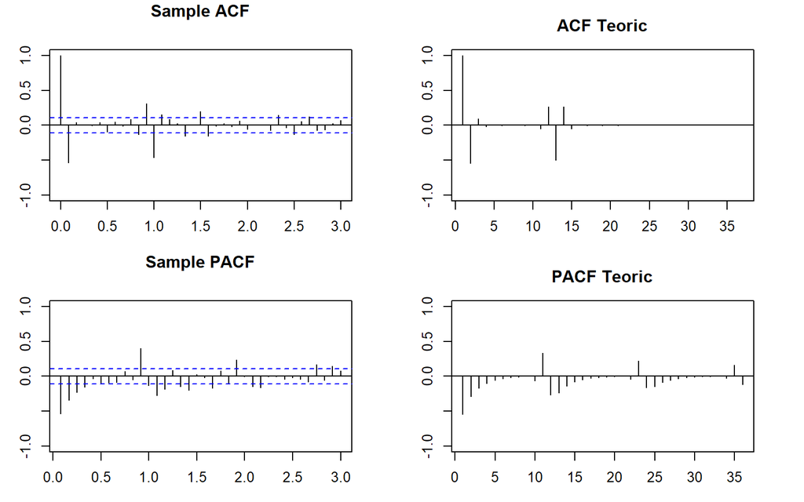

```r
validation(mod2, d1d12lnserie)
```

For this second model, we extract basically the same conclusions as in the first one. We also see very similar sample and theoretical ACF/PACF plots, with adequacy measures: log-likelihood, 613.46, the AIC, -1218.93 and $\sigma^2 = 0.001068$.

We see that all the ARMA model assumptions are not fulfilled completely, but for the moment we will accept the models as valid and later on we will treat calendar effects and outliers and see if we can improve the models.

## Forecasting

We have considered (for the moment) that both models are valid and fulfill the assumptions of an ARMA model. Now, we will see how the models perform on forecasting and select the best of them in that aspect. For that purpose, we will reserve the last 12 observations and do the following steps:

- Check if the models are stable
- Evaluate their capability of prediction
- Compare the performance of both models and select the best for forecasting

### Stability

> **Stability:**

> A time series is said to be stable if its statistical properties, such as mean, variance, and autocorrelation, remain constant or change only gradually over time.

So, for an ARIMA model, stability ensures that the model produces accurate forecasts and reflects the underlying patterns of the time series data.

Note that we will reserve the last 12 observations of the time series in order to make long-term predictions with the models and be able to compare with real data.

```r
ultim = c(2018,12)
pdq_1 = c(0,1,1)
pdq_2 = c(1,1,1)
PDQ = c(0,1,1)

serie2=window(lnserie,end=ultim)
serie1=window(lnserie,end=ultim+c(1,0))
```

For model 1:

```r
(mod1A=arima(serie1,order=pdq_1,seasonal=list(order=PDQ,period=12)))
```

```
##
## Call:
## arima(x = serie1, order = pdq_1, seasonal = list(order = PDQ, period = 12))
##
## Coefficients:
##           ma1     sma1
##       -0.6756  -0.8916
## s.e.   0.0355   0.0472
##
## sigma^2 estimated as 0.001081:  log likelihood = 610.97,  aic = -1215.93
```

```r
(mod1B=arima(serie2,order=pdq_1,seasonal=list(order=PDQ,period=12)))
```

```
##
## Call:
## arima(x = serie2, order = pdq_1, seasonal = list(order = PDQ, period = 12))
##
## Coefficients:
##           ma1     sma1
##       -0.6831  -0.9097
## s.e.   0.0360   0.0497
##
## sigma^2 estimated as 0.001085:  log likelihood = 585.44,  aic = -1164.87
```

The parameters seem to be preserved: magnitudes are similar, signs are the same and they are all significant. We will consider the model to be stable.

Let’s check for model 2:

```r
(mod2A=arima(serie1,order=pdq_2,seasonal=list(order=PDQ,period=12)))
```

```
##
## Call:
## arima(x = serie1, order = pdq_2, seasonal = list(order = PDQ, period = 12))
##
## Coefficients:
##           ar1      ma1     sma1
##       -0.1707  -0.6006  -0.8770
## s.e.   0.0747   0.0562   0.0455
##
## sigma^2 estimated as 0.001068:  log likelihood = 613.46,  aic = -1218.93
```

```r
(mod2B=arima(serie2,order=pdq_2,seasonal=list(order=PDQ,period=12)))
```

```
##
## Call:
## arima(x = serie2, order = pdq_2, seasonal = list(order = PDQ, period = 12))
##
## Coefficients:
##           ar1      ma1     sma1
##       -0.1588  -0.6123  -0.8942
## s.e.   0.0769   0.0572   0.0472
##
## sigma^2 estimated as 0.001076:  log likelihood = 587.49,  aic = -1166.98
```

Again, we see very similar parameters in both fitted models, so we consider model 2 to be stable too.

### Forecasting performance

We have already seen that both models seem to be stable. Now, we will try to select the best one for forecasting. To do so, we will compute long-term predictions for both of them (12 months ahead) and compare with the real time series to obtain some metrics to be able to compare both models.

```r
# Model 1
pred1 = predict(mod1B,n.ahead=12)
pr1 <- ts(c(tail(serie2,1),pred1$pred),start=ultim,freq=12)
se1 <- ts(c(0,pred1$se),start=ultim,freq=12)

tl1<-ts(exp(pr1-1.96*se1),start=ultim,freq=12)
tu1<-ts(exp(pr1+1.96*se1),start=ultim,freq=12)
pr1<-ts(exp(pr1),start=ultim,freq=12)

# Model 2
pred2 = predict(mod2B,n.ahead=12)
pr2 <- ts(c(tail(serie2,1),pred2$pred),start=ultim,freq=12)
se2 <- ts(c(0,pred2$se),start=ultim,freq=12)

tl2<-ts(exp(pr2-1.96*se2),start=ultim,freq=12)
tu2<-ts(exp(pr2+1.96*se2),start=ultim,freq=12)
pr2<-ts(exp(pr2),start=ultim,freq=12)
```

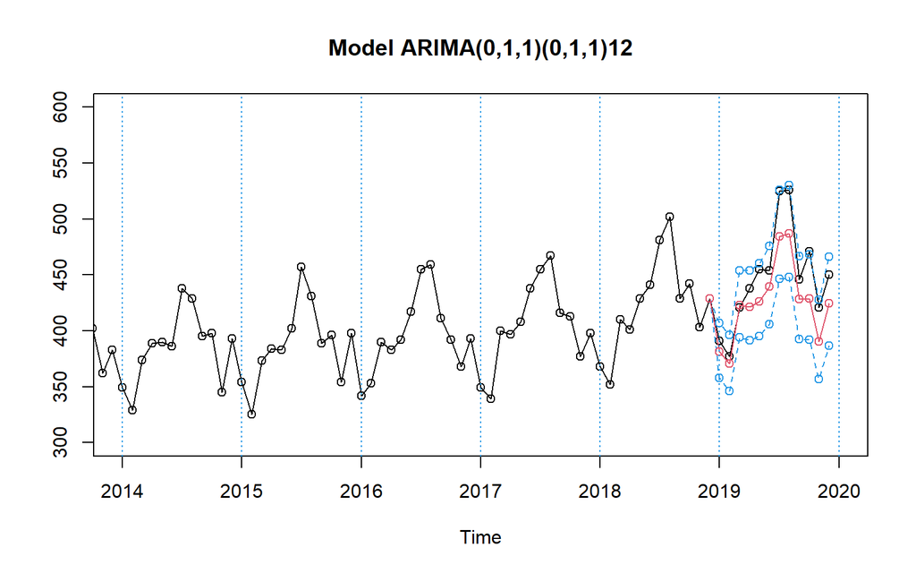

```r
ts.plot(serie,tl1,tu1,pr1,lty=c(1,2,2,1),col=c(1,4,4,2),xlim=c(2014,2020),ylim=c(300,600),type="o",main=paste("Model ARIMA(",paste(pdq_1,collapse=","),")(",paste(PDQ,collapse=","),")12",sep=""))
abline(v=2014:2020,lty=3,col=4)
```

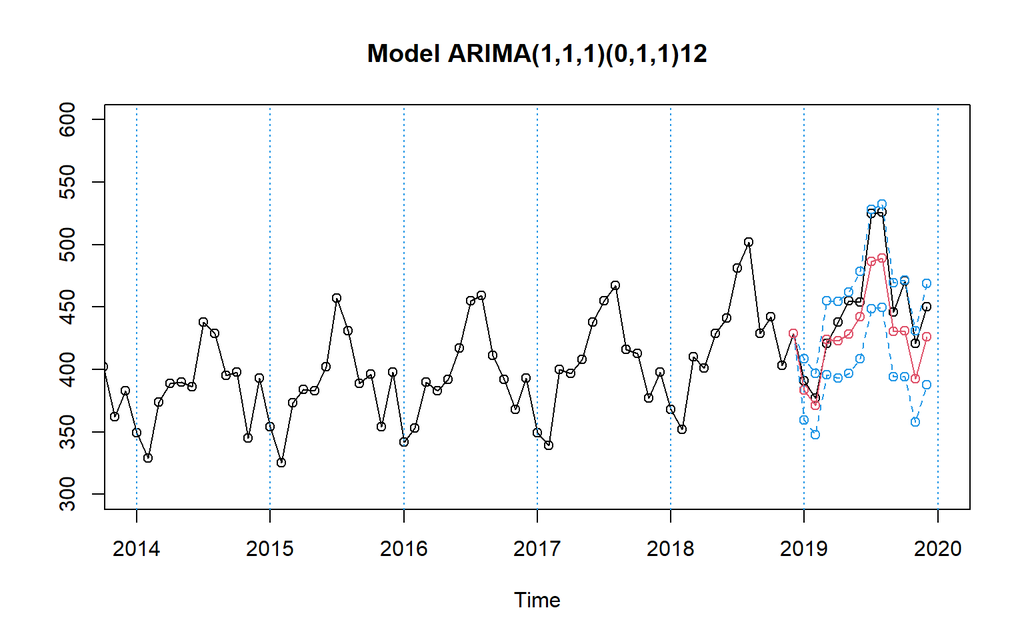

```r
ts.plot(serie,tl2,tu2,pr2,lty=c(1,2,2,1),col=c(1,4,4,2),xlim=c(2014,2020),ylim=c(300,600),type="o",main=paste("Model ARIMA(",paste(pdq_2,collapse=","),")(",paste(PDQ,collapse=","),")12",sep=""))
abline(v=2014:2020,lty=3,col=4)
```

We see that the predictions of both models look almost identical. However, as we are trying to select the best one for forecasting, we will extract some metrics about the predictions:

```r
obs=window(serie,start=ultim)

mod1.RMSE=sqrt(sum((obs-pr1)^2)/12)
mod1.MAE=sum(abs(obs-pr1))/12
mod1.RMSPE=sqrt(sum(((obs-pr1)/obs)^2)/12)
mod1.MAPE=sum(abs(obs-pr1)/obs)/12
mod1.ML=sum(tu1-tl1)/12

metrics1 <- data.frame("Model"=paste("ARIMA(",paste(pdq_1,collapse=","),")(",paste(PDQ,collapse=","),")12",sep=""),"RMSE"=mod1.RMSE,"MAE"=mod1.MAE,"RMSPE"=mod1.RMSPE,"MAPE"=mod1.MAPE,"Mean length"=mod1.ML)

mod2.RMSE=sqrt(sum((obs-pr2)^2)/12)
mod2.MAE=sum(abs(obs-pr2))/12
mod2.RMSPE=sqrt(sum(((obs-pr2)/obs)^2)/12)
mod2.MAPE=sum(abs(obs-pr2)/obs)/12
mod2.ML=sum(tu2-tl2)/12

metrics2 <- data.frame("Model"=paste("ARIMA(",paste(pdq_2,collapse=","),")(",paste(PDQ,collapse=","),")12",sep=""), "RMSE"=mod2.RMSE,"MAE"=mod2.MAE,"RMSPE"=mod2.RMSPE,"MAPE"=mod2.MAPE,"Mean length"=mod2.ML)

metrics <- rbind(metrics1, metrics2)
metrics
```

```
##                   Model     RMSE      MAE      RMSPE       MAPE Mean.length
## 1 ARIMA(0,1,1)(0,1,1)12 26.30145 22.79890 0.05549803 0.04915055    68.35688
## 2 ARIMA(1,1,1)(0,1,1)12 24.52005 21.10482 0.05161301 0.04542351    68.68324
```

Although the metrics are very similar, we choose the $ARMA(1,1,1)(0,1,1)_{12}$ as the best one for prediction, as it has better RMSE, MAE, RMSPE and MAPE, despite having a little less precision (Mean Length of the intervals).

```r
mod = mod2A
```

# Predictions

Now that we have selected the best model for forecasting, we are able to make predictions for the twelve months following the last observation available. That is, from January to December 2020.

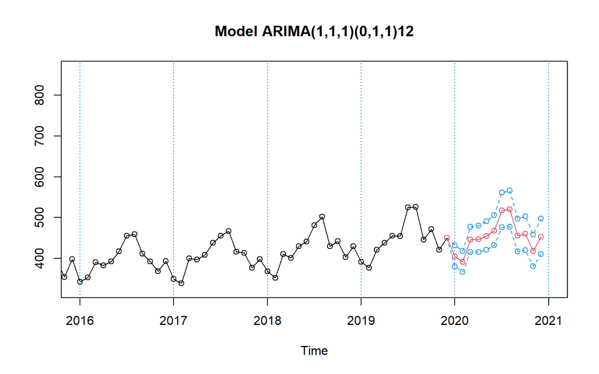

```r
pred=predict(mod,n.ahead=12)
pr<-ts(c(tail(lnserie,1),pred$pred),start=ultim+c(1,0),freq=12)
se<-ts(c(0,pred$se),start=ultim+c(1,0),freq=12)

#Intervals
tl<-ts(exp(pr-1.96*se),start=ultim+c(1,0),freq=12)
tu<-ts(exp(pr+1.96*se),start=ultim+c(1,0),freq=12)
pr<-ts(exp(pr),start=ultim+c(1,0),freq=12)

ts.plot(serie,tl,tu,pr,lty=c(1,2,2,1),col=c(1,4,4,2),xlim=c(ultim[1]-2,ultim[1]+3),type="o",main="Model ARIMA(1,1,1)(0,1,1)12")
abline(v=(ultim[1]-2):(ultim[1]+3),lty=3,col=4)
```

With the selected model, we would obtain these predictions, which we see are quite similar to the previous years.

# Outlier treatment

When we validated the models, we saw that some of the assumptions of ARIMA models were not completely fulfilled, probably due to the presence of outliers. We will now take them into consideration, in order to be able to improve the fitted models. The first step will be to check if calendar effects are significant or not and later on we will appply automatic detection of outliers.

## Calendar effects

Calendar effects refer to recurring patterns in time series data that are influenced by the calendar. In our case, we will focus on the effect of trading days (we do not have the same number of weekends every month) and Easter (which does not always fall on the same dates of the year). We could also account for more specific effects related to the topic of our particular time series, but as we do not have more information about the effects on the gasoline consumption, we have decided not to include them. We will use the prepared script **CalendarEffects.r**, which we have already been using during the course.

```r
source("CalendarEffects.r")
data=c(start(lnserie)[1],start(lnserie)[2], length(lnserie))

wTradDays=Wtrad(data)
wEast=Weaster(data)
```

After setting the calendar effects, we fit the four possible models: the original one (the one that we have decided that worked best for prediction), one taking into account trading days, one taking into account the effect of Easter and one taking both effects into account.

```r
# Original model
(mod2=arima(lnserie,order=pdq_2,seasonal=list(order=PDQ,period=12)))
```

```
##
## Call:
## arima(x = lnserie, order = pdq_2, seasonal = list(order = PDQ, period = 12))
##
## Coefficients:
##           ar1      ma1     sma1
##       -0.1707  -0.6006  -0.8770
## s.e.   0.0747   0.0562   0.0455
##
## sigma^2 estimated as 0.001068:  log likelihood = 613.46,  aic = -1218.93
```

```r
t(round(mod2$coef/sqrt(diag(mod2$var.coef)),2))
```

```
##        ar1    ma1   sma1
## [1,] -2.28 -10.68 -19.26
```

```r
# Model with trading days
(mod2TD=arima(lnserie,order=pdq_2,seasonal=list(order=PDQ,period=12),xreg=wTradDays))
```

```
##
## Call:
## arima(x = lnserie, order = pdq_2, seasonal = list(order = PDQ, period = 12),
##     xreg = wTradDays)
##
## Coefficients:
##           ar1      ma1     sma1  wTradDays
##       -0.1308  -0.5741  -0.8762     0.0039
## s.e.   0.0817   0.0644   0.0448     0.0005
##
## sigma^2 estimated as 0.0009057:  log likelihood = 639.24,  aic = -1268.48
```

```r
t(round(mod2TD$coef/sqrt(diag(mod2TD$var.coef)),2))
```

```
##       ar1   ma1   sma1 wTradDays
## [1,] -1.6 -8.92 -19.54      7.55
```

```r
# Model with Easter effects
(mod2Ea=arima(lnserie,order=pdq_2,seasonal=list(order=PDQ,period=12),xreg=wEast))
```

```
##
## Call:
## arima(x = lnserie, order = pdq_2, seasonal = list(order = PDQ, period = 12),
##     xreg = wEast)
##
## Coefficients:
##           ar1      ma1     sma1   wEast
##       -0.1463  -0.6048  -0.8707  0.0264
## s.e.   0.0759   0.0566   0.0457  0.0084
##
## sigma^2 estimated as 0.001038:  log likelihood = 618.25,  aic = -1226.51
```

```r
t(round(mod2Ea$coef/sqrt(diag(mod2Ea$var.coef)),2))
```

```
##        ar1    ma1   sma1 wEast
## [1,] -1.93 -10.69 -19.03  3.14
```

```r
# Model with both trading days and Easter effects
(mod2EC=arima(lnserie,order=pdq_2,seasonal=list(order=PDQ,period=12),xreg=data.frame(wTradDays,wEast)))
```

```
##
## Call:
## arima(x = lnserie, order = pdq_2, seasonal = list(order = PDQ, period = 12),
##     xreg = data.frame(wTradDays, wEast))
##
## Coefficients:
##           ar1      ma1     sma1  wTradDays   wEast
##       -0.0863  -0.5820  -0.8679      4e-03  0.0316
## s.e.   0.0842   0.0655   0.0451      5e-04  0.0074
##
## sigma^2 estimated as 0.0008584:  log likelihood = 647.95,  aic = -1283.9
```

```r
t(round(mod2EC$coef/sqrt(diag(mod2EC$var.coef)),2))
```

```
##        ar1   ma1   sma1 wTradDays wEast
## [1,] -1.03 -8.89 -19.23      8.19  4.29
```

We see that calendar effects are significant. In all of the cases we obtain a ratio of the absolute values of the coefficients and the standard errors greater than 2 for the calendar effects. However, we see that for the model with both effects, the ratio for the AR(1) coefficient is near 1. We decide to do the same with the other model that we fitted previously (the $ARIMA(0,1,1)(0,1,1)_{12}$) to see if we avoid this effect.

```r
# Original model
(mod1=arima(lnserie,order=pdq_1,seasonal=list(order=PDQ,period=12)))
```

```
##
## Call:
## arima(x = lnserie, order = pdq_1, seasonal = list(order = PDQ, period = 12))
##
## Coefficients:
##           ma1     sma1
##       -0.6756  -0.8916
## s.e.   0.0355   0.0472
##
## sigma^2 estimated as 0.001081:  log likelihood = 610.97,  aic = -1215.93
```

```r
t(round(mod1$coef/sqrt(diag(mod1$var.coef)),2))
```

```
##         ma1   sma1
## [1,] -19.03 -18.89
```

```r
# Model with trading days
(mod1TD=arima(lnserie,order=pdq_1,seasonal=list(order=PDQ,period=12),xreg=wTradDays))
```

```
##
## Call:
## arima(x = lnserie, order = pdq_1, seasonal = list(order = PDQ, period = 12),
##     xreg = wTradDays)
##
## Coefficients:
##           ma1     sma1  wTradDays
##       -0.6406  -0.8862     0.0038
## s.e.   0.0389   0.0458     0.0005
##
## sigma^2 estimated as 0.0009103:  log likelihood = 637.99,  aic = -1267.97
```

```r
t(round(mod1TD$coef/sqrt(diag(mod1TD$var.coef)),2))
```

```
##         ma1   sma1 wTradDays
## [1,] -16.48 -19.34      7.71
```

```r
# Model with Easter effects
(mod1Ea=arima(lnserie,order=pdq_1,seasonal=list(order=PDQ,period=12),xreg=wEast))
```

```
##
## Call:
## arima(x = lnserie, order = pdq_1, seasonal = list(order = PDQ, period = 12),
##     xreg = wEast)
##
## Coefficients:
##           ma1     sma1   wEast
##       -0.6700  -0.8821  0.0273
## s.e.   0.0363   0.0470  0.0081
##
## sigma^2 estimated as 0.001047:  log likelihood = 616.45,  aic = -1224.91
```

```r
t(round(mod1Ea$coef/sqrt(diag(mod1Ea$var.coef)),2))
```

```
##         ma1   sma1 wEast
## [1,] -18.45 -18.78  3.35
```

```r
# Model with both trading days and Easter effects
(mod1EC=arima(lnserie,order=pdq_1,seasonal=list(order=PDQ,period=12),xreg=data.frame(wTradDays,wEast)))
```

```
##
## Call:
## arima(x = lnserie, order = pdq_1, seasonal = list(order = PDQ, period = 12),
##     xreg = data.frame(wTradDays, wEast))
##
## Coefficients:
##           ma1     sma1  wTradDays   wEast
##       -0.6275  -0.8735      4e-03  0.0320
## s.e.   0.0407   0.0456      5e-04  0.0072
##
## sigma^2 estimated as 0.00086:  log likelihood = 647.43,  aic = -1284.85
```

```r
t(round(mod1EC$coef/sqrt(diag(mod1EC$var.coef)),2))
```

```
##         ma1   sma1 wTradDays wEast
## [1,] -15.42 -19.14      8.32  4.44
```

With this model, we obtain significance in all of the coefficients and also on the Calendar Effects. We decide to stay with $mod1EC$, the model that takes into account both effects (trading days and Easter).

After that, we correct the original series with both effects:

```r
EfecTD=coef(mod1EC)["wTradDays"]*wTradDays
EfecSS=coef(mod1EC)["wEast"]*wEast
lnserieEC=lnserie-EfecTD-EfecSS

d1d12lnserieEC <- diff(diff(lnserieEC, 12), 1)
```

And we see the ACF/PACF structure to see if the previously selected model still makes sense:

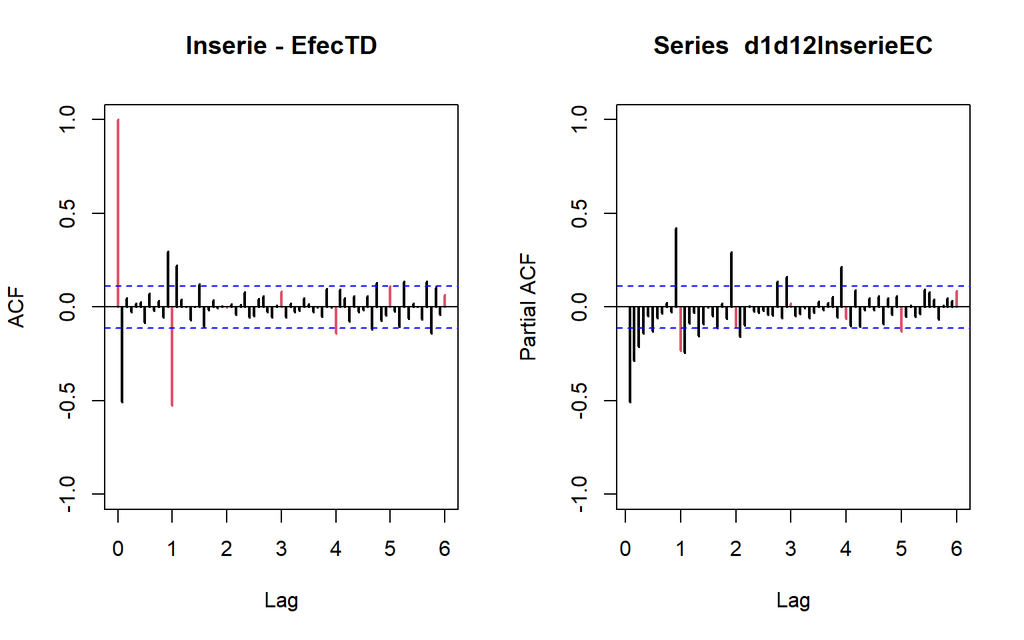

```r
par(mfrow=c(1,2))
acf(d1d12lnserieEC,ylim=c(-1,1),lag.max=72,col=c(2,rep(1,11)),lwd=2)
pacf(d1d12lnserieEC,ylim=c(-1,1),lag.max=72,col=c(rep(1,11),2),lwd=2)
```

```r
par(mfrow=c(1,1))
```

From the ACF/PACF structure of the corrected series, we see that the $MA(1)$ structure for both the normal and the seasonal part makes sense. We then continue with this model:

```r
(mod1EC=arima(lnserie,order=c(0,1,1),seasonal=list(order=c(0,1,1),period=12),xreg=data.frame(wTradDays,wEast)))
```

```
##
## Call:
## arima(x = lnserie, order = c(0, 1, 1), seasonal = list(order = c(0, 1, 1), period = 12),
##     xreg = data.frame(wTradDays, wEast))
##
## Coefficients:
##           ma1     sma1  wTradDays   wEast
##       -0.6275  -0.8735      4e-03  0.0320
## s.e.   0.0407   0.0456      5e-04  0.0072
##
## sigma^2 estimated as 0.00086:  log likelihood = 647.43,  aic = -1284.85
```

After seeing that both the effects of Easter and trading days are significant, we plot their effects and we compare the original series with the one taking them into account:

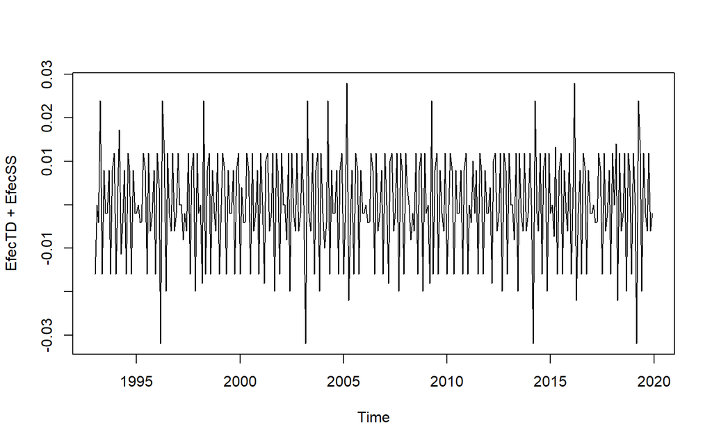

```r
plot(EfecTD + EfecSS)
```

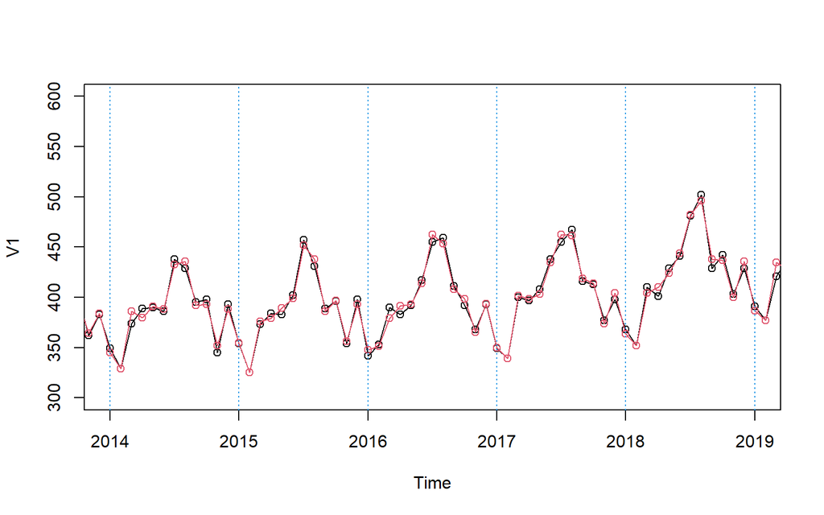

```r
serieEC=exp(lnserieEC)
plot(serie,xlim=c(2014,2019), ylim=c(300,600),type="o")
lines(serieEC,col=2,type="o")
abline(v=2014:2019,lty=3,col=4)
```

We do not see big differences, but in some points they are noticeable. We have decided to go on with the $ARIMA(0,1,1)(0,1,1)_{12}$ model, but before treating the outliers, we will perform a validation after having treated the calendar effects, to see if we have improved the model already:

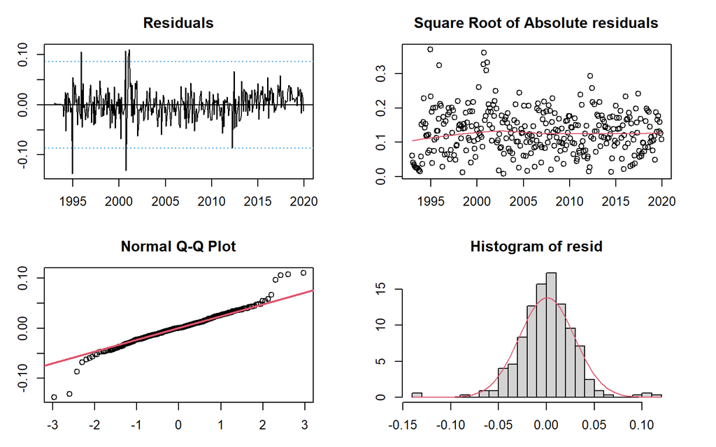

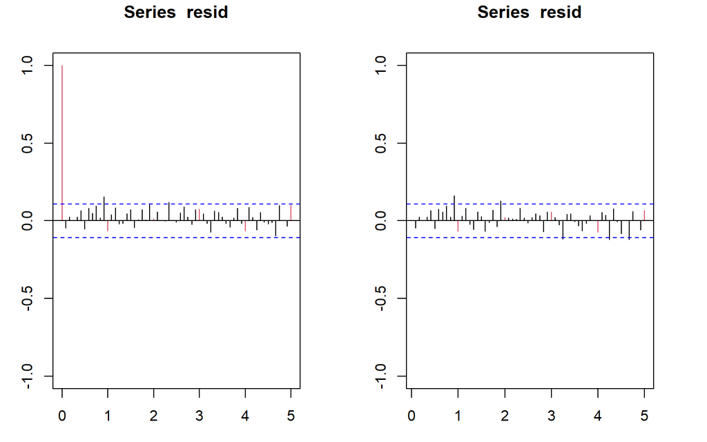

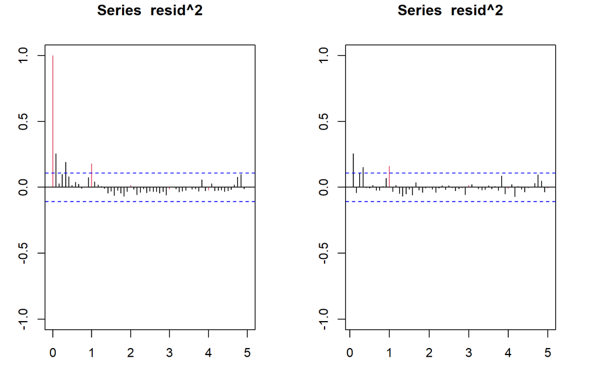

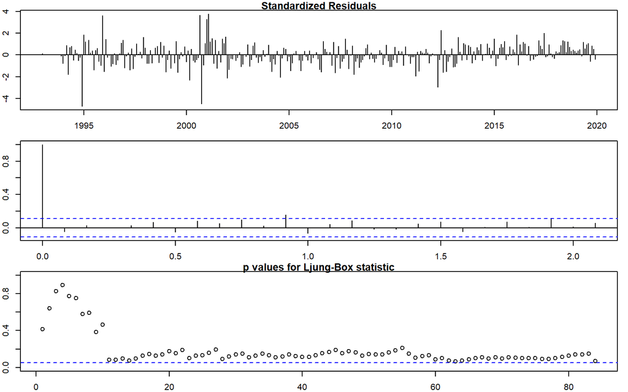

```
##
## --------------------------------------------------------------------
##
## Call:
## arima(x = lnserie, order = c(0, 1, 1), seasonal = list(order = c(0, 1, 1), period = 12),
##     xreg = data.frame(wTradDays, wEast))
##
## Coefficients:
##           ma1     sma1  wTradDays   wEast
##       -0.6275  -0.8735      4e-03  0.0320
## s.e.   0.0407   0.0456      5e-04  0.0072
##
## sigma^2 estimated as 0.00086:  log likelihood = 647.43,  aic = -1284.85
##
## Modul of AR Characteristic polynomial Roots:
##
## Modul of MA Characteristic polynomial Roots:  1.011339 1.011339 1.011339 1.011339 1.011339 1.011339 1.011339 1.011339 1.011339 1.011339 1.011339 1.011339 1.593747
##
## Psi-weights (MA(inf))
##
## --------------------
##      psi 1      psi 2      psi 3      psi 4      psi 5      psi 6      psi 7
## -0.6274524  0.0000000  0.0000000  0.0000000  0.0000000  0.0000000  0.0000000
##      psi 8      psi 9     psi 10     psi 11     psi 12     psi 13     psi 14
##  0.0000000  0.0000000  0.0000000  0.0000000 -0.8734540  0.5480508  0.0000000
##     psi 15     psi 16     psi 17     psi 18     psi 19     psi 20
##  0.0000000  0.0000000  0.0000000  0.0000000  0.0000000  0.0000000
##
## Pi-weights (AR(inf))
##
## --------------------
##         pi 1         pi 2         pi 3         pi 4         pi 5         pi 6
## -0.627452357 -0.393696460 -0.247025772 -0.154996902 -0.097253172 -0.061021732
##         pi 7         pi 8         pi 9        pi 10        pi 11        pi 12
## -0.038288229 -0.024024040 -0.015073940 -0.009458179 -0.005934557 -0.877177664
##        pi 13        pi 14        pi 15        pi 16        pi 17        pi 18
## -0.550387192 -0.345341741 -0.216685489 -0.135959821 -0.085308310 -0.053526900
##        pi 19        pi 20
## -0.033585580 -0.021073351
##
```

[output cut: 38 more lines]

```
## data:  resid(model) ~ I(1:length(resid(model)))
## DW = 2.1181, p-value = 0.8438
## alternative hypothesis: true autocorrelation is greater than 0
##
##
## Ljung-Box test
##      lag.df  statistic    p.value
## [1,]      1  0.6687405 0.41349105
## [2,]      2  0.8856560 0.64221767
## [3,]      3  0.8860145 0.82880144
## [4,]      4  1.1060073 0.89331791
## [5,]     12 19.3159309 0.08118404
## [6,]     24 31.9259582 0.12883943
## [7,]     36 46.6548583 0.11000657
## [8,]     48 57.4457941 0.16496040
```

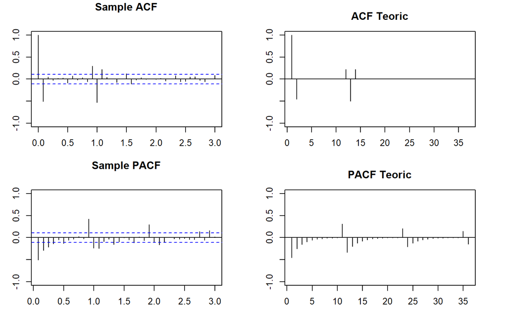

```r
validation(mod1EC, d1d12lnserieEC)
```

With respect to the model without the calendar effects treatment we see:

- The effects that were due to outliers are still noticeable (heavy tails on the Q-Q and histogram that avoid normality, for example).
- The residuals are now independent: the main change is in the Ljung-Box test. However, this may change when we remove the outliers, as it can be a side effect of them.

## Outliers

After having treated the calendar effects, we will now apply automatic detection of outliers. As we have done during the course, we will use the **atipics2.r** script. We will apply it to the model we have fitted taking into account the calendar effects, as it is the one that has worked the best so far.

```r
source("atipics2.r")
```

```r
mod.atip=outdetec(mod1EC,dif=c(1,12),crit=2.75,LS=T)

#Estimated residual variance after outliers detection and treatment
mod.atip$sigma
```

```
## [1] 0.0004088337
```

We will see which outliers we have detected and interpret them briefly:

```r
atipics=mod.atip$atip[order(mod.atip$atip[,1]),]
meses=c("Ene","Feb","Mar","Abr","May","Jun","Jul","Ago","Sep","Oct","Nov","Dic")

data.frame(atipics,Fecha=paste(meses[(atipics[,1]-1)%%12+1],start(lnserie)[1]+((atipics[,1]-1)%/%12)),perc.Obs=exp(atipics[,3])*100)
```

```
##    Obs type_detected     W_coeff ABS_L_Ratio    Fecha  perc.Obs
## 11  16            AO -0.05219812    2.849971 Abr 1994  94.91408
## 2   24            AO -0.15520401    7.096257 Dic 1994  85.62405
## 7   36            AO  0.06154705    3.178841 Dic 1995 106.34805
## 9   38            TC  0.05700896    3.115858 Feb 1996 105.86653
## 3   93            LS  0.09368342    5.159803 Sep 2000 109.82120
## 1   94            TC -0.15479437    6.755273 Oct 2000  85.65913
## 6   97            LS  0.06472751    3.812044 Ene 2001 106.68683
## 14 101            LS -0.04350544    2.853709 May 2001  95.74273
## 8  108            AO  0.06196181    3.251384 Dic 2001 106.39217
## 10 171            AO  0.05282000    2.845049 Mar 2007 105.42399
## 13 183            LS -0.04434320    2.868806 Mar 2008  95.66256
## 12 219            LS -0.04383368    2.794768 Mar 2011  95.71131
## 4  232            LS -0.06581050    3.682608 Abr 2012  93.63083
## 5  234            AO  0.08165428    4.043845 Jun 2012 108.50806
```

From the results above, we see that our dataset has the three types of outliers which we have seen during the course: AO, LS and TC. In summary, an Additive Outlier (AO) is a single unusual spike, a Level Shift (LS) is a sudden change in the average value and a Transitory Change (TC) is a temporary spike that eventually goes away. We find these many cases of each type of outlier:

```r
table(atipics$type_detected)
```

```
##
## AO LS TC
##  6  6  2
```

We can interpret some of the results above, for instance:

- The 93rd observation is a level shift (LS) type of outlier. This coincides with a good economic period for Spain. Economic growth leads to increased industrial, commercial, and transportation activities, resulting in higher fuel demand. We find the opposite level shift in mid-2012, with a level shift in which the consumption of gasoline decreases. This 232nd observation coincides with the year of the second economic crisis, and the effect takes place from that moment on.
- The 24th observation is an additive outlier (AO) that occurs in December 1994. As we learned during the course. this type of outlier is only noticed at that specific date. We have not been able to explain what may have caused it. However, since we are working with a log-transformed series and we know that, for that significant observation, $\texttt{W_coeff} = -0.155$, if we apply the exponential function and multiply the result by 100%, we get the percentage relative variation effect. For this case, we know that whatever occurred in December 1994, caused the consumption of gasoline to only be $85.62\%$ of what would have been without the presence of this atypical phenomenon. This is an effect of a $14.38\%$ decrease.
- In October of the year 2000 (observation number 94), we observe a transitory change (TC) type of outlier with a significant statistic’s value |6.76|>2. Its magnitude is given by $\texttt{W_coeff} = -0.1548$ in the log-scale, which means that a decrease in the gasoline consumption in Spain is observed with respect to what would have happened if this atypical had not taken place. Again, we have not been able to detect any factor that caused such fluctuation, although in that same month there was a deadly terrorist attack by ETA involving a car bomb and ending in more than 60 injured civilians. However, we would not associate this with a transitory change.

Another interesting thing to see is the comparison between the original and the linearized series, where we should especially see level shifts and transitory changes:

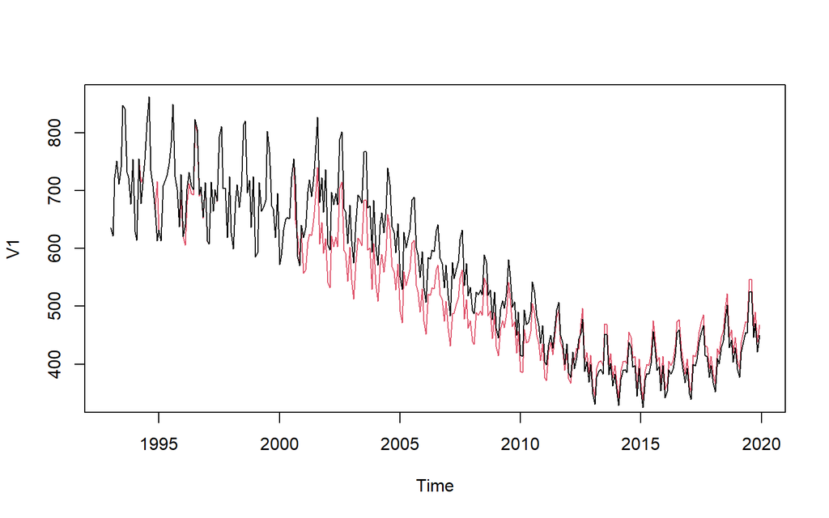

```r
lnserie.lin=lineal(lnserie,mod.atip$atip)
serie.lin=exp(lnserie.lin)

plot(serie.lin,col=2)
lines(serie)
```

Finally, we see the effect of the outliers:

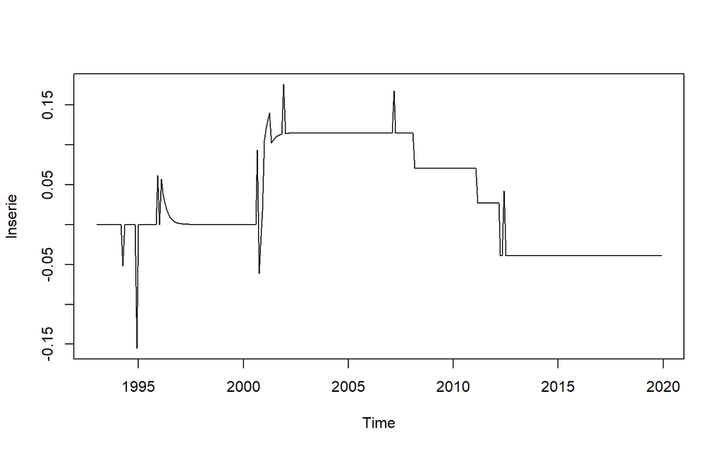

```r
plot(lnserie-lnserie.lin)
```

As we have done in the calendar effects treatment, we have to check if the currently used model is also suitable for the linearlized series. For that purpose, we plot the ACF/PACF structure of the linearlized series:

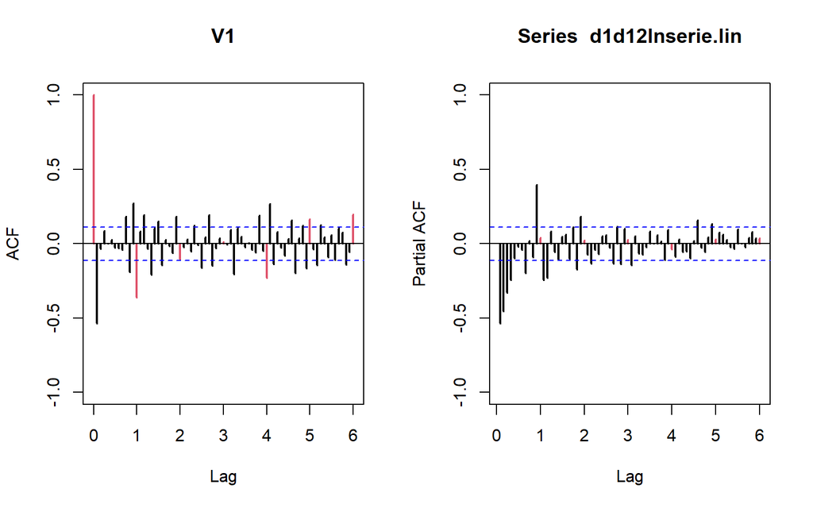

```r
d1d12lnserie.lin=diff(diff(lnserie.lin,12))
par(mfrow=c(1,2))
acf(d1d12lnserie.lin,ylim=c(-1,1),lag.max=72,col=c(2,rep(1,11)),lwd=2)
pacf(d1d12lnserie.lin,ylim=c(-1,1),lag.max=72,col=c(rep(1,11),2),lwd=2)
```